# Developing DP 2 Final

Kyriaki Roumpi

2022-12-23

## Project Instructions

This peer assessed assignment has two parts. First, you will create a Shiny application and deploy it on Rstudio’s servers. Second, you will use Slidify or Rstudio Presenter to prepare a reproducible pitch presentation about your application.

### Your Shiny Application

- Write a shiny application with associated supporting documentation. The documentation should be thought of as whatever a user will need to get started using your application.
- Deploy the application on Rstudio’s shiny server
- Share the application link by pasting it into the provided text box
- Share your server.R and ui.R code on github

The application must include the following:

- Some form of input (widget: textbox, radio button, checkbox, …)
- Some operation on the ui input in sever.R
- Some reactive output displayed as a result of server calculations
- You must also include enough documentation so that a novice user could use your application.

The documentation should be at the Shiny website itself. Do not post to an external link.

## Preparation

First we need to make a new project in R, which will basically be a new working directory (wd). Then, we download the packages we will need.

```r
library(shiny)
library(knitr)
```

```r
library(maps)
library(mapproj)
```

Then the data. We will use the rds “counties”, which includes all USA counties and offers information on the population percentages in each county. The reason for choosing this file is because I had already worked in previous projects with the “countries.rds” and I was already familiar with the content and the project I would do.

At this point, I must include that at the very beginning I made the mistake of adding an extra “r” in “countries” and when I realised it it was so late that I decided to change everything to “countries”.

*Note* : I wanted to do this project with a european map, but I couldn’t find a proper file online, so I went back to the USA map.

So we download the “counties.rds” file and put it in our wd.

```r
countries <- readRDS("C:/Users/diken/OneDrive/Desktop/App-1/counties.rds")
```

Of course, we need to familiarize ourselves with our data, so we use commands like head(), summary() and dim() to see what our data consists of.

## Basic procedure

The next step is to set the code source that will assist us in creating the app. For this step we will use the already set code of helpers.R which is available online. After we download it, we move it to our wd.

```r
source("C:/Users/diken/OneDrive/Desktop/App-1/helpers.R")
```

We will need to see the percentages on the map, so we will use the percentage_map call in R for that.

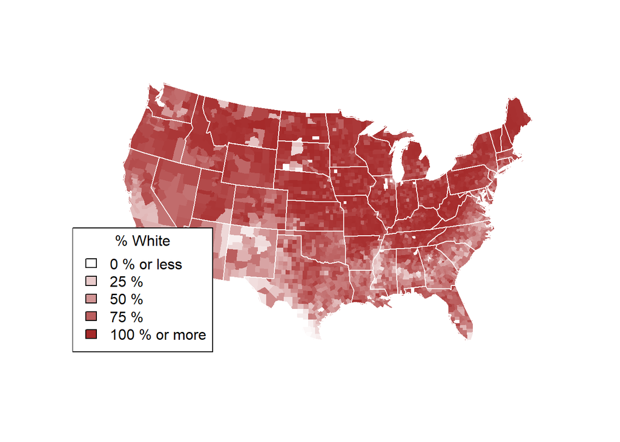

```r
percent_map(countries$white, "brown", "% White")
```

## UI object and server

With the following calls, we basically adjust and control the layout and function of our project.

```r
ui <- fluidPage(
     titlePanel("Ethnicities % USA counties"),
     sidebarLayout(
         sidebarPanel(
             helpText("Create demographic maps with information from the 2010 US Census."),
             selectInput("var",
               label = "Choose a variable to display",
               choices = c("Percent White", "Percent Black", "Percent Hispanic", "Percent Asian"),
               selected = "Percent White"),
             sliderInput("range",
               label = "Range of interest:",
               min = 0, max = 100, value = c(0, 100))
         ),
         mainPanel(plotOutput("map"))
     )
 )
```

```r
server <- function(input, output) {
    output$map <- renderPlot({
        countries2 <- switch(input$var,
                       "Percent White" = countries$white,
                       "Percent Black" = countries$black,
                       "Percent Hispanic" = countries$hispanic,
                       "Percent Asian" = countries$asian)

        percent_map(var = countries2, color = "brown", legend.title = "Ethnicity % of USA counties", max = 100, min = 1)
    })
}
```

## Final Call and Results

Normally up until that moment, you will have corrected possible errors that may have occured during the procedure. If not, after the following command, the final errors to be corrected will appear.

```r
shinyApp(ui, server)
```

Shiny applications not supported in static R Markdown documents